# Airline online performance analytics

Sreekantha Thimmareddy

10 October 2017

## Objective

Have you ever been stuck in an airport because your flight was delayed or cancelled and wondered if you could have predicted it if you’d had more data? This is to answer few questions in the context of Airline on-time performance:

. Which carrier performs better? . When is the best time of day/day of week/time of year to fly to minimise delays? . Do older planes suffer more delays? . Can you detect cascading failures as delays in one airport create delays in others? Are there critical links in the system? . Create a model to predict flight delays . How well does weather predict plane delays?

## Installing all required packaes

```
## R.methodsS3 v1.7.1 (2016-02-15) successfully loaded. See ?R.methodsS3 for help.
```

```
## R.oo v1.21.0 (2016-10-30) successfully loaded. See ?R.oo for help.
```

```
## R.utils v2.5.0 (2016-11-07) successfully loaded. See ?R.utils for help.
```

## Loading and Processing Data

```
## [1] "D:/Data Science/Flight Data Analysis"
```

```r
#Download data from Web
#download.file(url="http://stat-computing.org/dataexpo/2009/2007.csv.bz2", destfile = "./Data/2007.csv.bz2")
#download.file(url="http://stat-computing.org/dataexpo/2009/2008.csv.bz2", destfile = "./Data/2008.csv.bz2")
#download.file(url="http://stat-computing.org/dataexpo/2009/airports.csv", destfile = "./Data/airports.csv")
#download.file(url="http://stat-computing.org/dataexpo/2009/carriers.csv", destfile = "./Data/carriers.csv")
#download.file(url="http://stat-computing.org/dataexpo/2009/plane-data.csv", destfile = "./Data/plane_data.csv")

# Unzip files
#bunzip2("./Data/new/2007.csv.bz2", "./Data/2007.csv", remove = FALSE, skip = TRUE)
#bunzip2("./Data/new/2008.csv.bz2", "./Data/2008.csv", remove = FALSE, skip = TRUE)

# Loading data files and working with sample set
trips2007 <- fread(".\\Data\\2007.csv")  #Fastest way to load large files.
```

[output not shown]

```r
trips2008 <- fread(".\\Data\\2008.csv")
```

[output not shown]

```r
trips2007a <- sample_n(trips2007, 100000)
trips2008b <- sample_n(trips2008, 100000)

trips2007a <- as.data.table(trips2007a)
trips2008b <- as.data.table(trips2008b)

tripsfile <- rbind(trips2007a, trips2008b)

# To free up unused files.
rm(trips2007, trips2008)

## Load other supporting files as well.
airportsfile <- read.csv2('.\\Data\\airports.csv',sep = ",",header = TRUE)
carriersfile <- read.csv2('.\\Data\\carriers.csv',sep = ",",header = TRUE)
planedatafile <- read.csv2('.\\Data\\plane_data.csv',sep = ",",header = TRUE)

## This is to have copy of raw data untouched available for any reference.
trips <- tripsfile
airports <- airportsfile
carriers <- carriersfile
planedata <- planedatafile
```

## Feature Engineering

```r
summary(trips)
```

```
##       Year          Month          DayofMonth      DayOfWeek
##  Min.   :2007   Min.   : 1.000   Min.   : 1.00   Min.   :1.000
##  1st Qu.:2007   1st Qu.: 3.000   1st Qu.: 8.00   1st Qu.:2.000
##  Median :2008   Median : 6.000   Median :16.00   Median :4.000
##  Mean   :2008   Mean   : 6.435   Mean   :15.72   Mean   :3.926
##  3rd Qu.:2008   3rd Qu.: 9.000   3rd Qu.:23.00   3rd Qu.:6.000
##  Max.   :2008   Max.   :12.000   Max.   :31.00   Max.   :7.000
##
##     DepTime       CRSDepTime      ArrTime       CRSArrTime
##  Min.   :   1   Min.   :   1   Min.   :   1   Min.   :   1
##  1st Qu.: 929   1st Qu.: 928   1st Qu.:1107   1st Qu.:1115
##  Median :1327   Median :1320   Median :1512   Median :1518
##  Mean   :1336   Mean   :1328   Mean   :1481   Mean   :1494
##  3rd Qu.:1730   3rd Qu.:1719   3rd Qu.:1910   3rd Qu.:1905
##  Max.   :2400   Max.   :2359   Max.   :2400   Max.   :2400
##  NA's   :4163                  NA's   :4629
##  UniqueCarrier        FlightNum      TailNum          ActualElapsedTime
##  Length:200000      Min.   :   1   Length:200000      Min.   : 15.0
##  Class :character   1st Qu.: 604   Class :character   1st Qu.: 76.0
##  Mode  :character   Median :1538   Mode  :character   Median :109.0
##                     Mean   :2201                      Mean   :127.2
##                     3rd Qu.:3515                      3rd Qu.:157.0
##                     Max.   :7829                      Max.   :693.0
##                                                       NA's   :4681
##  CRSElapsedTime     AirTime         ArrDelay           DepDelay
##  Min.   :  1.0   Min.   :  0.0   Min.   : -76.000   Min.   : -61.00
##  1st Qu.: 79.0   1st Qu.: 55.0   1st Qu.: -10.000   1st Qu.:  -4.00
##  Median :110.0   Median : 85.0   Median :  -1.000   Median :  -1.00
##  Mean   :128.4   Mean   :103.8   Mean   :   9.215   Mean   :  10.72
##  3rd Qu.:158.0   3rd Qu.:132.0   3rd Qu.:  13.000   3rd Qu.:   9.00
##  Max.   :660.0   Max.   :613.0   Max.   :1469.000   Max.   :1487.00
##  NA's   :33      NA's   :4681    NA's   :4681       NA's   :4163
##     Origin              Dest              Distance          TaxiIn
##  Length:200000      Length:200000      Min.   :  31.0   Min.   :  0.000
##  Class :character   Class :character   1st Qu.: 324.0   1st Qu.:  4.000
##  Mode  :character   Mode  :character   Median : 580.0   Median :  6.000
##                                        Mean   : 725.4   Mean   :  6.745
##                                        3rd Qu.: 950.0   3rd Qu.:  8.000
##                                        Max.   :4962.0   Max.   :141.000
##                                                         NA's   :2167
```

[output cut: 9 more lines]

```
##  Min.   :   0.00   Min.   :   0.00   Min.   :  0.00   Min.   :  0.00
##  1st Qu.:   0.00   1st Qu.:   0.00   1st Qu.:  0.00   1st Qu.:  0.00
##  Median :   0.00   Median :   0.00   Median :  0.00   Median :  0.00
##  Mean   :   5.96   Mean   :   1.15   Mean   :  6.23   Mean   :  0.03
##  3rd Qu.:   0.00   3rd Qu.:   0.00   3rd Qu.:  0.00   3rd Qu.:  0.00
##  Max.   :1447.00   Max.   :1429.00   Max.   :653.00   Max.   :169.00
##  NA's   :78421     NA's   :78421     NA's   :78421    NA's   :78421
##  LateAircraftDelay
##  Min.   :  0.00
##  1st Qu.:  0.00
##  Median :  0.00
##  Mean   :  7.94
##  3rd Qu.:  0.00
##  Max.   :925.00
##  NA's   :78421
```

```r
head(filter(trips,  WeatherDelay == 0 ))
```

```
##   Year Month DayofMonth DayOfWeek DepTime CRSDepTime ArrTime CRSArrTime
## 1 2007     7          1         7    1009        940    1114       1050
## 2 2007    10         10         3    1544       1550    1649       1646
## 3 2007     4         16         1    1019       1020    1204       1159
## 4 2007     4          6         5     727        715     831        826
## 5 2007     7          4         3     741        745     846        900
## 6 2007     9          6         4    2244       2259     722        739
##   UniqueCarrier FlightNum TailNum ActualElapsedTime CRSElapsedTime AirTime
## 1            9E      5751  89309E                65             70      48
## 2            NW      1749  N771NC                65             56      34
## 3            DL      1184  N977DL               105             99      81
## 4            9E      3773  89079E                64             71      46
## 5            B6      1002  N627JB                65             75      37
## 6            US       144  N909AW               338            340     325
##   ArrDelay DepDelay Origin Dest Distance TaxiIn TaxiOut Cancelled
```

[output cut: 20 more lines]

We can see there are ~40% of values are NAs for WeatherDelay, NASDelays, SecurityDelay, LateAircraftDelay. We cannot eaither mark them as zero or backfill with other value. It’s best to omit and use remaining data or exclude these variables in prediction. We can try both. And in other variables, small number of NAs present and we can omit them as well.

```
## [1] 200000
```

```
## [1] 119117
```

Creating hour variables as the time is in HHMM format and not suitable for analysis.

```r
trips$ArrHour <- trunc(trips$CRSArrTime/100)
trips$DepHour <- trunc(trips$CRSDepTime/100)
```

Deviding day into 4 time periods for analysis have devided 24 hours into 4 buckets. i.e new variables DepTimeOfDay, ArrTimeOfDay - 12am to 5:59 am as 0 (Night) - 6am to 11:59 am as 1 (Morning) - 12noon to 5:59pm (Afternoon) - 6pm to 11:59pm (Evening)

```r
trips$ArrTimeofday <- trunc(trips$ArrHour/6)
trips$DepTimeofday <- trunc(trips$DepHour/6)
```

To see week of month has any significance. It may.

```r
trips$WeekOfMonth <- trunc(trips$DayofMonth/7+1)
```

Clearly based on data, the dependent variables are DepDelay and ArrDelay which is the total delay. Adding week of month.

### Joining the supporting data set.

Now let us merge/join supporting data set. This is to make one big de-normalized flat table with all the data fields required available. This can be done after initial EDA as well to find out which fields ussually to be included/excluded. Since I did some exploration in previous versions of code so doing it ahead before EDA here. First Planedata, not all fields are important. Also need to delete any NAs as we don’t have source to backfill.

```
## [1] 3376
```

```
## [1] 3364
```

```
##  num [1:119117] 9 8 NA 7 7 7 5 4 4 2 ...
```

## Exploratory Data Analysis

Let’s do EDA and find out significance of the variables in predicting Flight Delays For Continous variables, we can use co-relation to see how y is co-related to x1, x2 etc.. which is a good starting point to include in the model. For Categorical variables, let’s find if there are patterns.

Also, let us try and answer some of the questions we defined in the objective.

## Which Carrier performs better ?

This is bit generic question. Based on Case Study context “Airlines on-time performance”. We can make an assumption that the ask is in terms of flight delays

```r
str(trips)
```

```
## Classes 'data.table' and 'data.frame':   119117 obs. of  34 variables:
##  $ Year             : int  2007 2007 2007 2007 2007 2007 2007 2007 2007 2007 ...
##  $ Month            : int  7 10 4 4 7 9 9 3 11 7 ...
##  $ DayofMonth       : int  1 10 16 6 4 6 29 13 21 18 ...
##  $ DayOfWeek        : int  7 3 1 5 3 4 6 2 3 3 ...
##  $ DepTime          : int  1009 1544 1019 727 741 2244 1458 904 1917 719 ...
##  $ CRSDepTime       : int  940 1550 1020 715 745 2259 1455 911 1903 720 ...
##  $ ArrTime          : int  1114 1649 1204 831 846 722 1642 931 2046 825 ...
##  $ CRSArrTime       : int  1050 1646 1159 826 900 739 1615 937 2020 811 ...
##  $ UniqueCarrier    : chr  "9E" "NW" "DL" "9E" ...
##  $ FlightNum        : int  5751 1749 1184 3773 1002 144 1608 497 1713 122 ...
##  $ TailNum          : chr  "89309E" "N771NC" "N977DL" "89079E" ...
##  $ ActualElapsedTime: int  65 65 105 64 65 338 104 87 89 126 ...
##  $ CRSElapsedTime   : int  70 56 99 71 75 340 80 86 77 111 ...
##  $ AirTime          : int  48 34 81 46 37 325 91 65 55 99 ...
```

[output cut: 21 more lines]

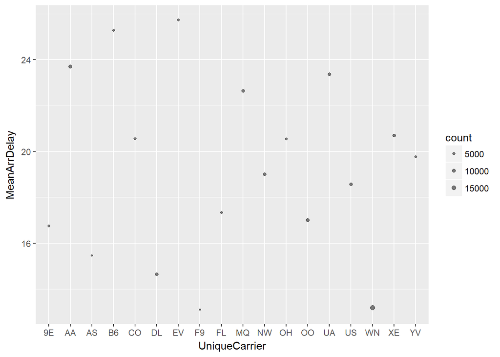

```r
CarrierDelay <- trips %>%
                  group_by(UniqueCarrier) %>%
                  summarise(count=n(), MeanArrDelay = mean(ArrDelay), MeanDepDelay=mean(DepDelay), MeanNASDelay=mean(NASDelay)) %>%
                  filter ( count > 1000, !is.na(MeanArrDelay), !is.na(MeanDepDelay) ) %>%
                  collect

#plot
ggplot(CarrierDelay, aes(UniqueCarrier, MeanArrDelay)) + geom_point(aes(size=count), alpha=1/2) +  scale_size_area(max_size = 2)
```

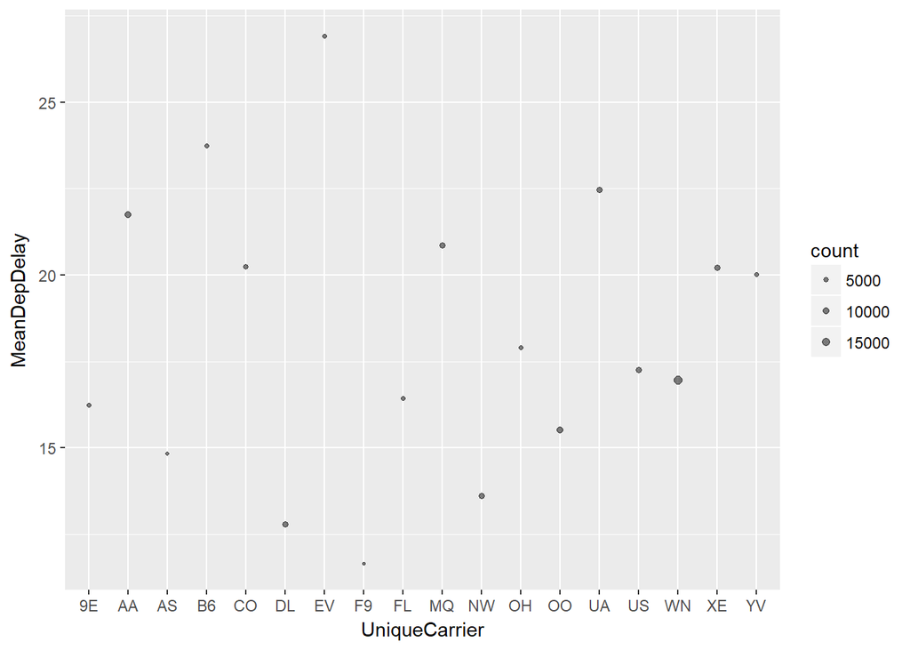

```r
ggplot(CarrierDelay, aes(UniqueCarrier, MeanDepDelay)) + geom_point(aes(size=count), alpha=1/2) +  scale_size_area(max_size = 2)
```

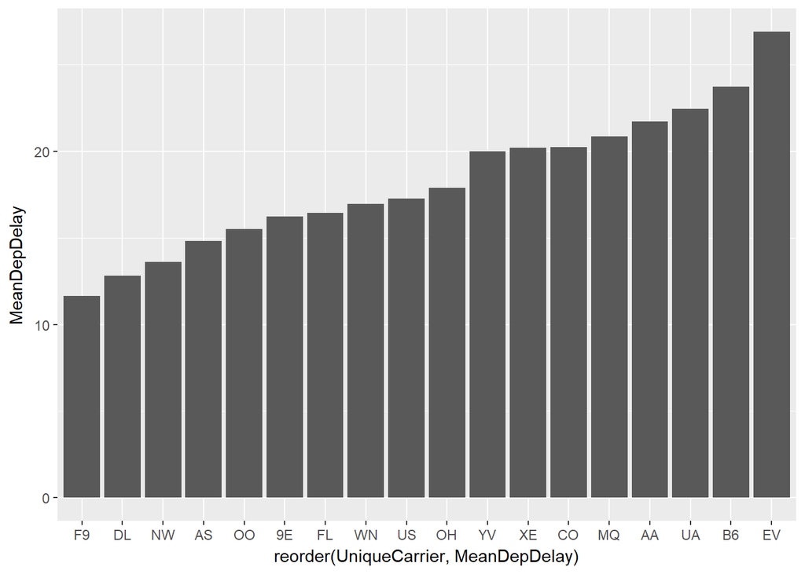

```r
# Same stuff with Bar chart.
ggplot(CarrierDelay, aes(reorder(UniqueCarrier, MeanDepDelay), MeanDepDelay)) + geom_bar( stat = "identity")
```

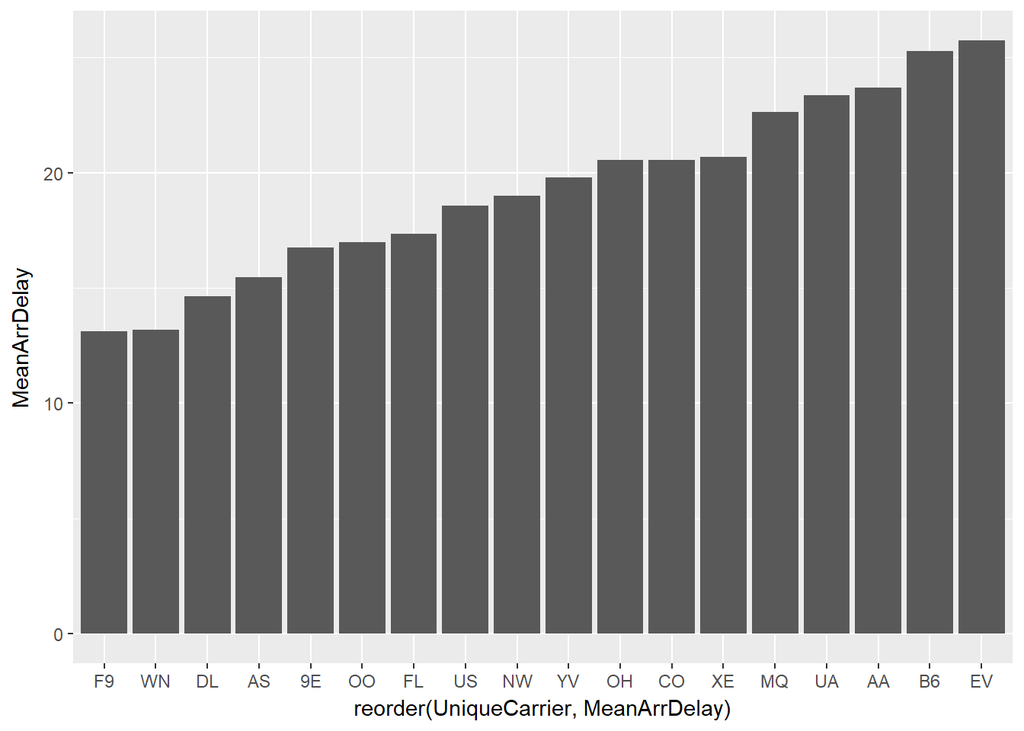

```r
ggplot(CarrierDelay, aes(reorder(UniqueCarrier, MeanArrDelay), MeanArrDelay)) + geom_bar( stat = "identity")
```

We can see that Carrier = WN has managed beter on-time perfornance with Arrival (avg ~14min delay) better even with large number of trips(), while DL has done better with Departure ( avg ~ 14min delay)

Again, Carrier performance differs between Airport to Airport. We can easily apply filter on Airport and get best parforming of Carrier. Or write a simple function to do the same.

#### Origin Airports - Performance

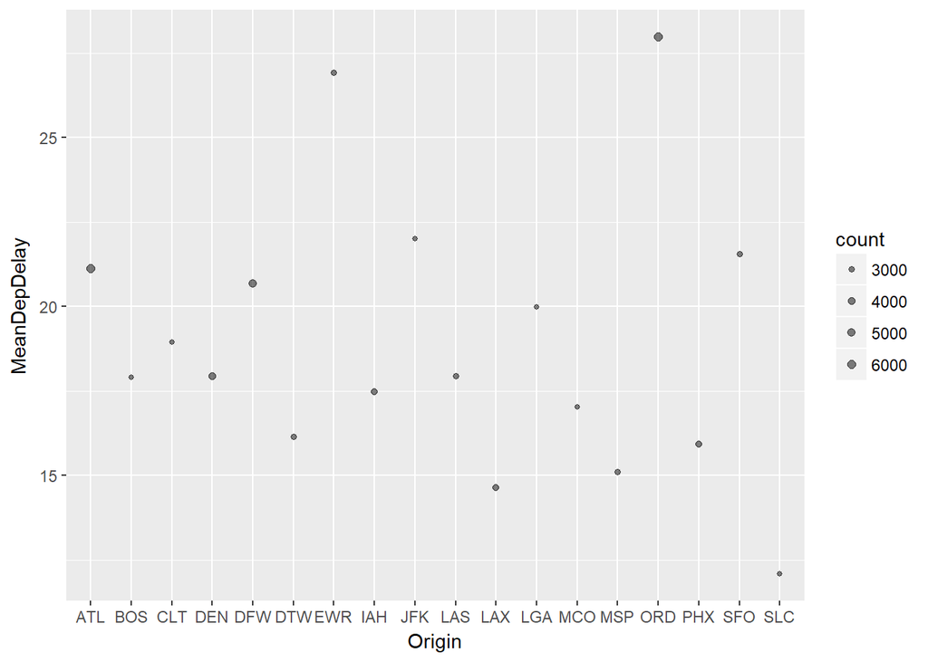

```r
OriginAirportDelay <- trips %>%
  group_by(Origin) %>%
  summarise(count=n(), MeanArrDelay = mean(ArrDelay), MeanDepDelay=mean(DepDelay), MeanWeatherDelay=mean(WeatherDelay)) %>%
  filter ( count > 2000, !is.na(MeanArrDelay), !is.na(MeanDepDelay) ) %>%
  collect
# Increasing count to 2000 for filtering in order to avoid too much cluttering.

#plot
ggplot(OriginAirportDelay, aes(Origin, MeanDepDelay)) + geom_point(aes(size=count), alpha=1/2) + geom_smooth() + scale_size_area(max_size = 2)
```

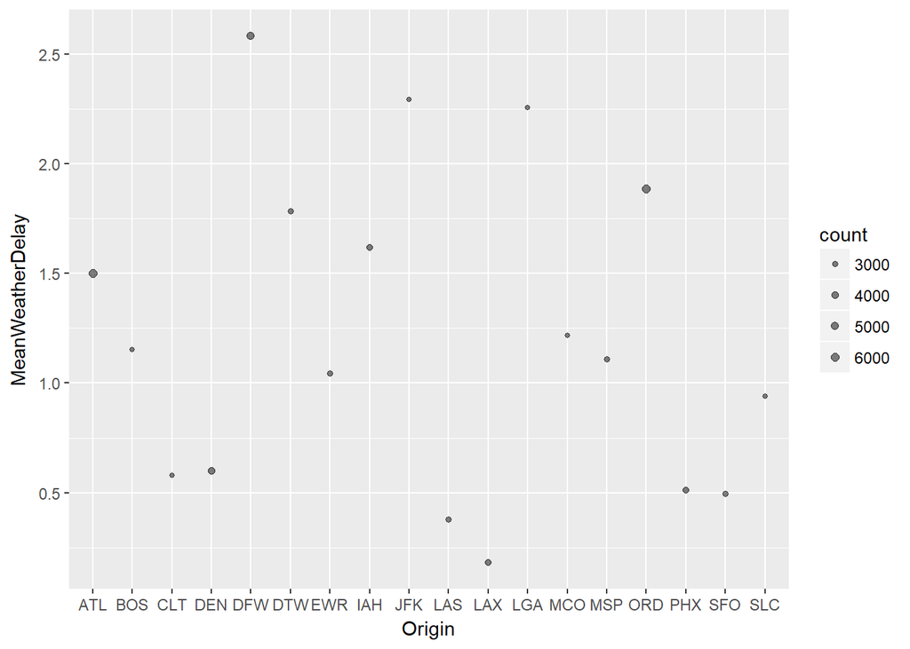

```r
ggplot(OriginAirportDelay, aes(Origin, MeanWeatherDelay)) + geom_point(aes(size=count), alpha=1/2) + geom_smooth() + scale_size_area(max_size = 2)
```

Lax and SLS are doing better for Departure. Weather is also not much impacted at LAX compared to others. However, except these airports, there is no perticular pattern we can observe. May be we need to combine other variables.

##### Dest Airports - performance

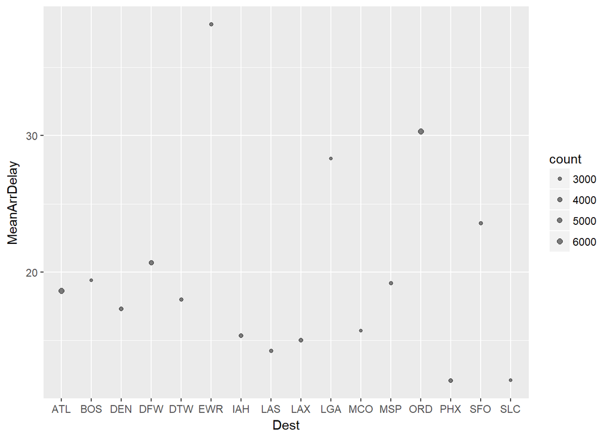

```r
DestAirportDelay <- trips %>%
  group_by(Dest) %>%
  summarise(count=n(), MeanArrDelay = mean(ArrDelay), MeanDepDelay=mean(DepDelay), MeanWeatherDelay2=mean(WeatherDelay)) %>%
  filter ( count > 2000, !is.na(MeanArrDelay), !is.na(MeanDepDelay) ) %>%
  collect
#
#plot
ggplot(DestAirportDelay, aes(Dest, MeanArrDelay)) + geom_point(aes(size=count), alpha=1/2) + geom_smooth() + scale_size_area(max_size = 2)
```

## When is the best time of the day/week/month/year to travel to minimize delays ?

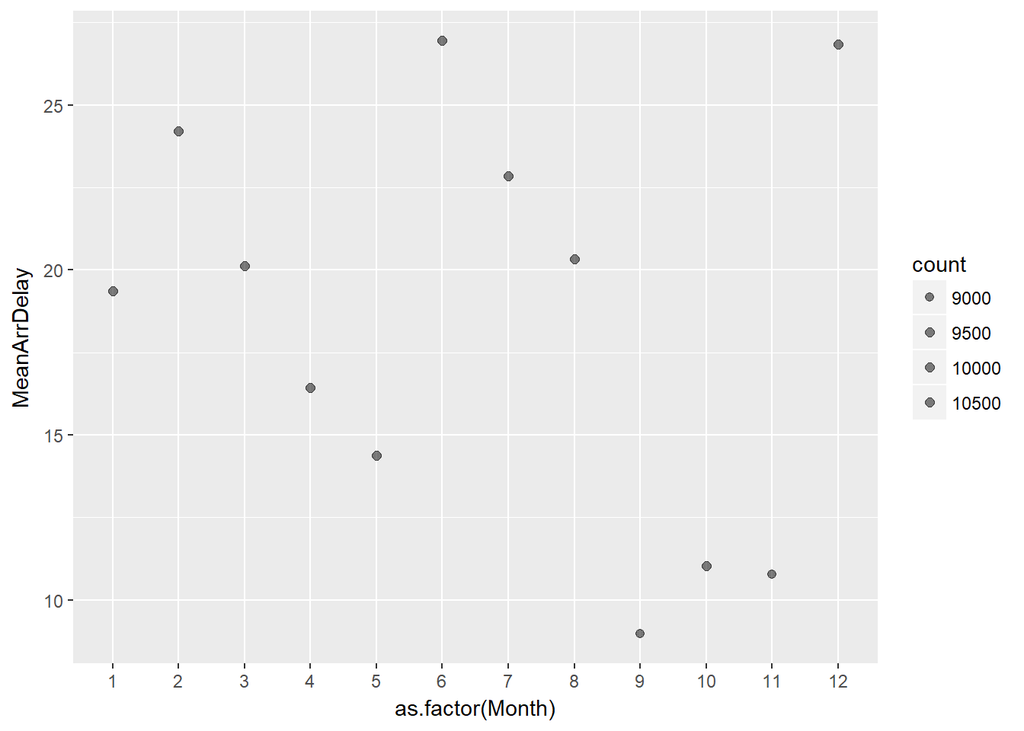

```r
DayMonthDelay <- trips %>%
  group_by(Month) %>%
  summarise(count=n(), MeanArrDelay = mean(ArrDelay), MeanDepDelay=mean(DepDelay), MeanWeatherDelay2=mean(WeatherDelay)) %>%
  filter ( count > 50, !is.na(MeanArrDelay), !is.na(MeanDepDelay) ) %>%
  collect

#plot
ggplot(DayMonthDelay, aes(as.factor(Month), MeanArrDelay)) + geom_point(aes(size=count), alpha=1/2) + geom_smooth() + scale_size_area(max_size = 2)
```

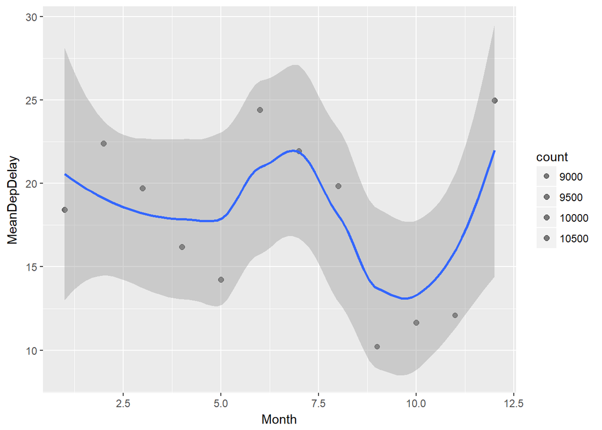

```r
ggplot(DayMonthDelay, aes(Month, MeanDepDelay)) + geom_point(aes(size=count), alpha=1/2) + geom_smooth() + scale_size_area(max_size = 2)
```

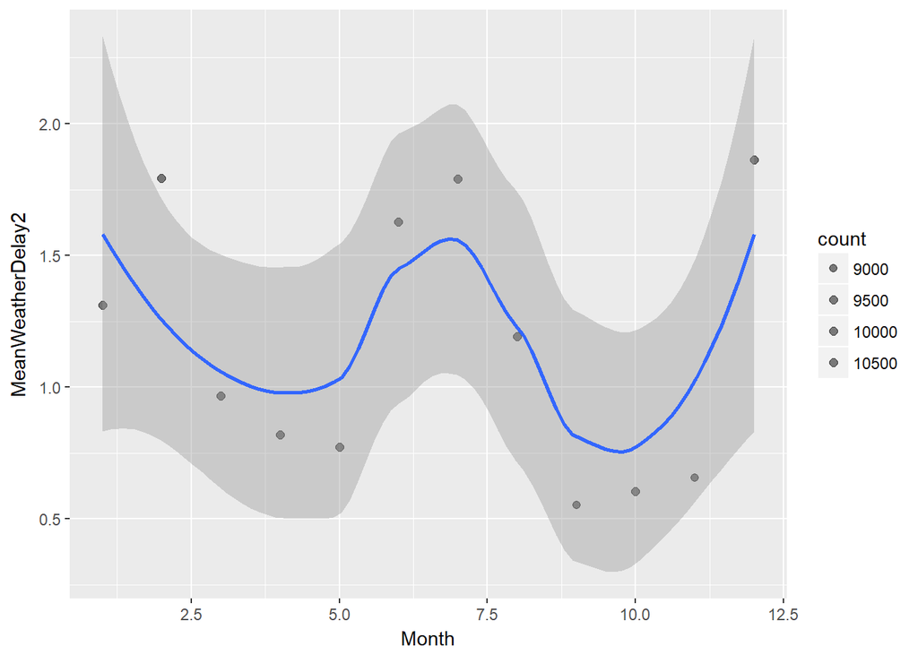

```r
ggplot(DayMonthDelay, aes(Month, MeanWeatherDelay2)) + geom_point(aes(size=count), alpha=1/2) + geom_smooth() + scale_size_area(max_size = 2)
```

We can clearly see Sept, Oct, Nov are the best months to fly as the delays are very min.

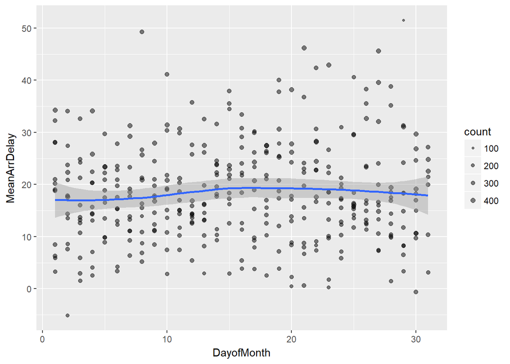

```r
DayofMonthDelay <- trips %>%
  group_by(Month,DayofMonth) %>%
  summarise(count=n(), MeanArrDelay = mean(ArrDelay), MeanDepDelay=mean(DepDelay), MeanWeatherDelay2=mean(WeatherDelay)) %>%
  filter ( count > 50, !is.na(MeanArrDelay), !is.na(MeanDepDelay) ) %>%
  collect

ggplot(DayofMonthDelay, aes(DayofMonth, MeanArrDelay)) + geom_point(aes(size=count), alpha=1/2) + geom_smooth() + scale_size_area(max_size = 2)
```

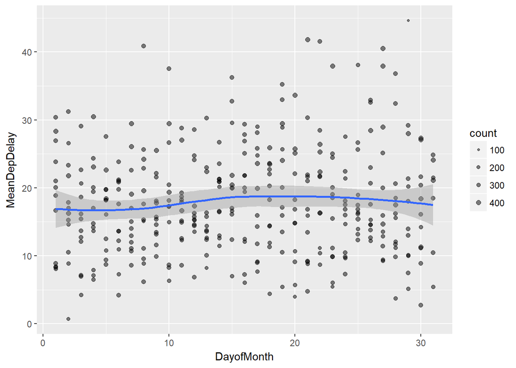

```r
ggplot(DayofMonthDelay, aes(DayofMonth, MeanDepDelay)) + geom_point(aes(size=count), alpha=1/2) + geom_smooth() + scale_size_area(max_size = 2)
```

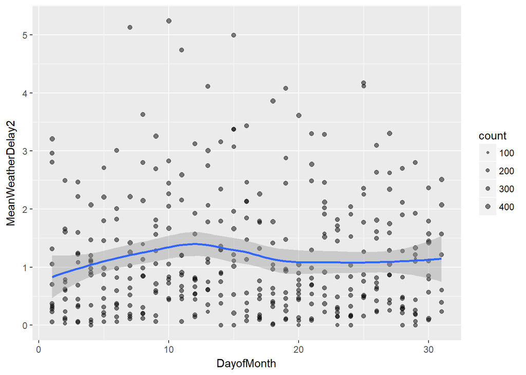

```r
ggplot(DayofMonthDelay, aes(DayofMonth, MeanWeatherDelay2)) + geom_point(aes(size=count), alpha=1/2) + geom_smooth() + scale_size_area(max_size = 2)
```

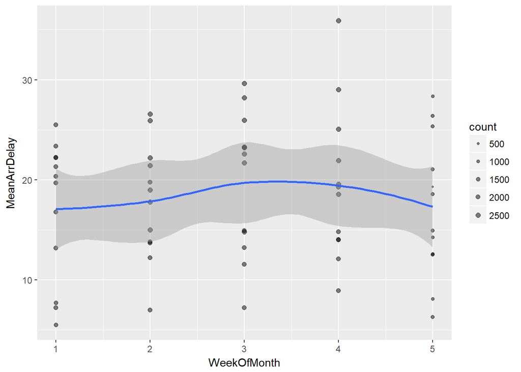

```r
# There is no patteren what so ever. No point in usng this as variable. However, we can try deviding the same by 7 and get the week info to see if there is a patteren.

WeekOfMonthDelay <- trips %>%
  group_by(Month,WeekOfMonth) %>%
  summarise(count=n(), MeanArrDelay = mean(ArrDelay), MeanDepDelay=mean(DepDelay), MeanWeatherDelay2=mean(WeatherDelay)) %>%
  filter ( count > 50, !is.na(MeanArrDelay), !is.na(MeanDepDelay) ) %>%
  collect


ggplot(WeekOfMonthDelay, aes(WeekOfMonth, MeanArrDelay)) + geom_point(aes(size=count), alpha=1/2) + geom_smooth() + scale_size_area(max_size = 2)
```

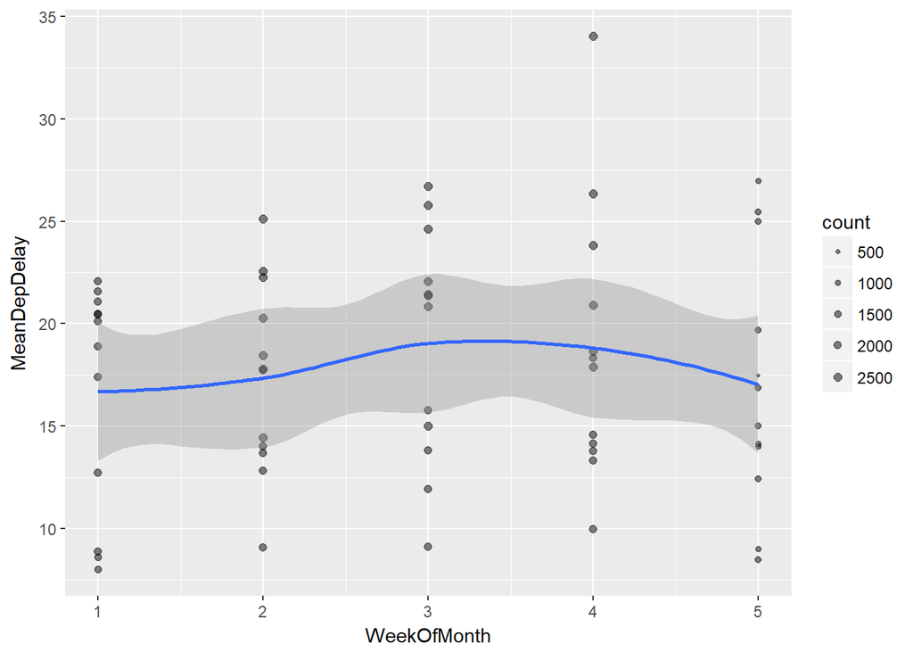

```r
ggplot(WeekOfMonthDelay, aes(WeekOfMonth, MeanDepDelay)) + geom_point(aes(size=count), alpha=1/2) + geom_smooth() + scale_size_area(max_size = 2)
```

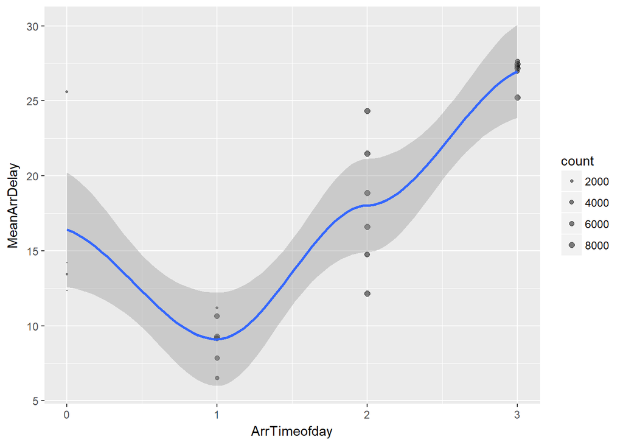

```r
TimeArrDelay <- trips %>%
  group_by(ArrHour,ArrTimeofday) %>%
  summarise(count=n(), MeanArrDelay = mean(ArrDelay), MeanDepDelay=mean(DepDelay), MeanWeatherDelay2=mean(WeatherDelay)) %>%
  filter ( count > 50, !is.na(MeanArrDelay), !is.na(MeanDepDelay) ) %>%
  collect

ggplot(TimeArrDelay, aes(ArrTimeofday, MeanArrDelay)) + geom_point(aes(size=count), alpha=1/2) + geom_smooth() + scale_size_area(max_size = 2)
```

Plan your flight such a way, your sheduled arrival is morning. i.e better overall.

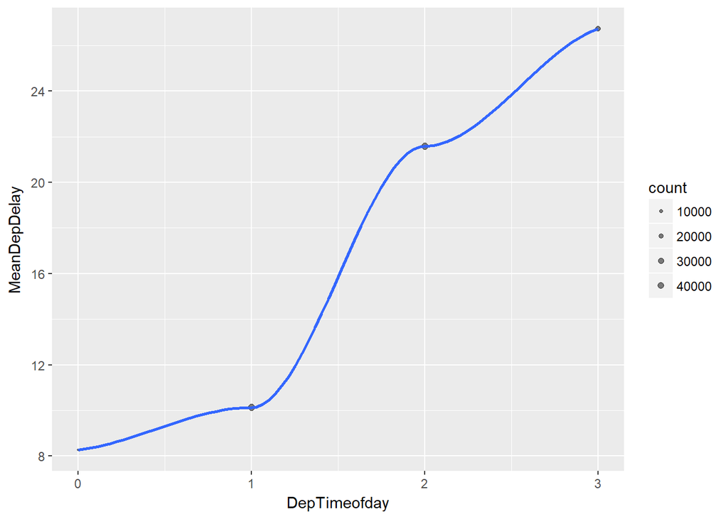

```r
TimeDepDelay <- trips %>%
  group_by(DepTimeofday) %>%
  summarise(count=n(), MeanArrDelay = mean(ArrDelay), MeanDepDelay=mean(DepDelay), MeanWeatherDelay2=mean(WeatherDelay)) %>%
  filter ( count > 50, !is.na(MeanArrDelay), !is.na(MeanDepDelay) ) %>%
  collect

ggplot(TimeDepDelay, aes(DepTimeofday, MeanDepDelay)) + geom_point(aes(size=count), alpha=1/2) + geom_smooth() + scale_size_area(max_size = 2)
```

Generally Departure delays keeps increasing as day prgress. So early morning flights are better.

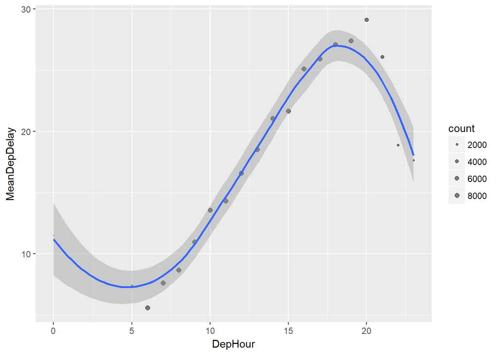

```r
HourDepDelay <- trips %>%
  group_by(DepHour) %>%
  summarise(count=n(), MeanArrDelay = mean(ArrDelay), MeanDepDelay=mean(DepDelay), MeanWeatherDelay2=mean(WeatherDelay)) %>%
  filter ( count > 50, !is.na(MeanArrDelay), !is.na(MeanDepDelay) ) %>%
  collect

ggplot(HourDepDelay, aes(DepHour, MeanDepDelay)) + geom_point(aes(size=count), alpha=1/2) + geom_smooth() + scale_size_area(max_size = 2)
```

Clearly 5-10am departures are better. and almost very negligible delays of less then ~10min.